# Part II - Factors That Affect the Scheduled Monthly Loan Payment

## by Oluwadamilotun Kehinde Oguntuga

## Investigation Overview

> In this investigation, I was interested in determining the factors that affect the scheduled monthly loan payment. My focus was on twelve variables of dataset. The features that stood out in the analysis include the employment status, term of the loan, debt-to-income ratio and the number of investors. These are the features that will be explained in this presentation.

## Dataset Overview

> The Prosper Loan dataset contains one hundred and thirteen thousand records of loans given by Prosper. It contains the details of the borrower information and how the loans are being serviced. It also documents the variables surrounding the borrowing of the loans such as the number of investors, monthly loan payments. The dataset contains a risk score known as the Prosper Score issued by prosper to assess the borrowers based on past loans.

## Distribution of the Scheduled Monthly Loan Payments

The scheduled monthly loan payment showed a bimodal distribution which is right-skewed. The modal scheduled monthly loan payment was about 200.

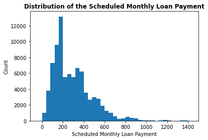

```
''
```

## Average Monthly Loan Payment vs Employment Status

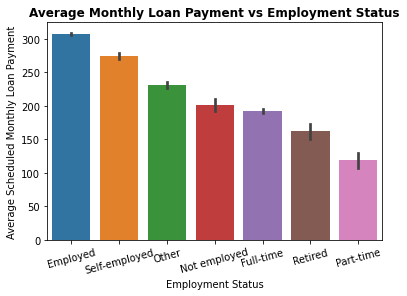

## Relationship between the average scheduled monthly loan payment and the employment status for the different terms of the loan.

This investigates the distribution of the average monthly loan payment for each employment status over the three terms of the loan present. It was noticed that more self employed loanees took out loans for 12 month and had the highest average monthly loan payment in this period.

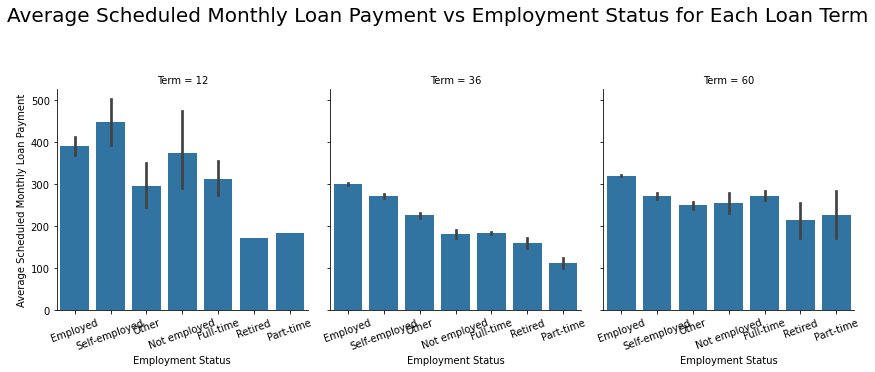

## Scheduled Monthly Loan Payment vs Number of Investors

This comparison was done with a heatmap that showed an area of high density where the number of investors was very low and the monthly loan payment also was very low. Hence, most loanees had few investors and paid lower amounts monthly.

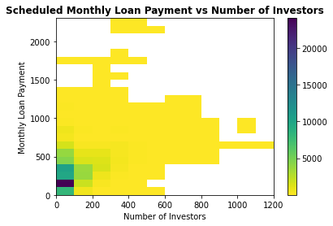

```
''
```

## Effect of the the Debt-to-Income Ratio on the Relationship Between Scheduled Monthly Loan Payment and the Number of Investors

Color encoding was used to depict the effect of the debt-to-income ratio and it was discovered that most of the loanees had ratios that are less that 0.5.

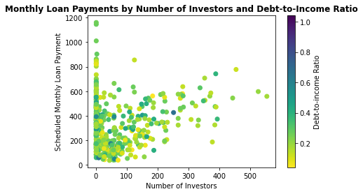

## Relationship Between the Scheduled Monthly Loan Payment and Number of Investors in Terms of the Duration(Term) of the Loan.

This investigation showed that the loanees with the highest monthly loan payment had no investors and took the loan for 36 months.

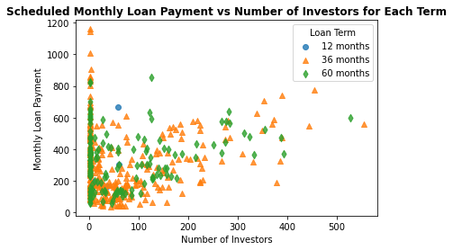

```
''
```